# Student Engagement in the International Politics Department 2025/26

Author

Stefano Pagliari

Published

May 1, 2026

# 1 In-Person Attendance

The analysis in this section explores the in-person attendance in the UG modules in the International Politics Department in 2025/26. It draws on approximately 76,000 session records extracted from the attendance monitoring system at City St George’s. Attendance status for each session is determined by swipe records: a student is recorded as having attended if a valid swipe entry is present for that session. For the purpose of this analysis, late tapping is treated as attendance. The analysis focuses on undergraduate compulsory teaching sessions that are listed on the central timetabling website, excluding optional modules and sessions not formally scheduled.

These records are imperfect. Occasional technical failures may result in missed registrations, and the known phenomenon of “tap and leave” — where a student swipes in but does not remain for the session — means that recorded attendance may overstate actual engagement in some cases. For the purposes of this analysis, late tapping is recorded as attendance. As far as can be determined, however, these data quality issues are not systematically associated with the main factors analysed below. While they inflate the overall attendance rate, they should not materially distort the analysis of correlates. The analysis also necessarily misses cases where students attend a session without tapping their card, or where they attend a class not assigned to them in the timetable — neither of which is captured in the timetabling system.

The section proceeds in three stages. The first provides a descriptive overview of overall attendance trends in the IP Department for 2025/26, situating these figures in context by comparison with the previous academic year (2024/25) and, where data are available, with attendance patterns in other departments at City St George’s. This contextual comparison is intended to establish whether observed attendance levels are distinctive to the IP Department or reflect university-wide trends. The second stage examines variation in attendance across modules, cohorts, and session types within the IP Department, identifying where attendance is strongest and where it is weakest. Finally, a mixed-effects logistic regression model to isolate the independent contribution of a range of factors to the probability of a student attending any given session.

## 1.1 Attendance in 2025/26 in Context

### 1.1.1 Attendance Across Years

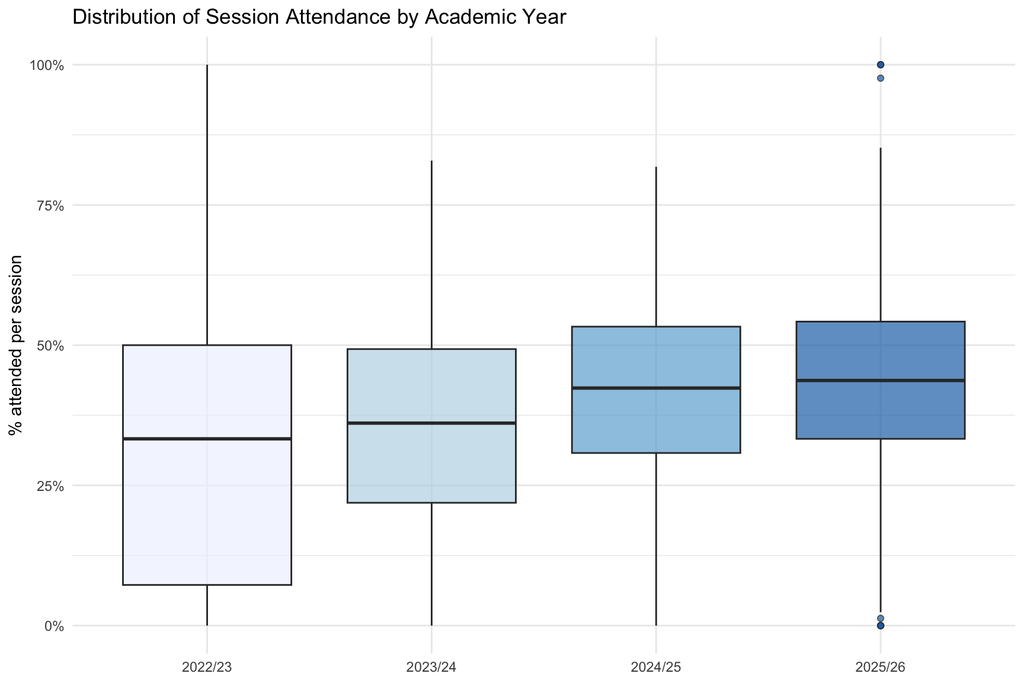

Attendance in 2025/26 shows a modest improvement compared to 2024/25. However, comparisons with years prior to 2024/25 should be treated with caution given the different notification and reminder system for domestic students who failed to attend classes before 2024/25. To the extent that more consistent or more frequent reminders were introduced or adjusted around 2024/25, earlier years may not be directly comparable.

### 1.1.2 Comparison with City Departments

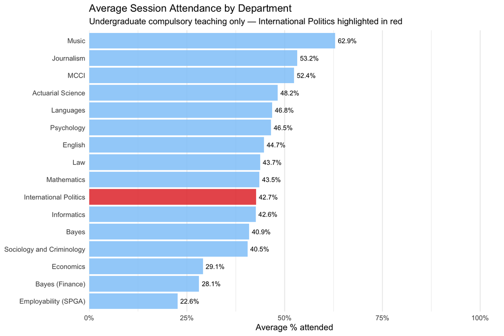

Attendance in the Department of International Politics in 2025/26 sit in the middle compared across City’s undergraduate provision, and the pattern becomes clearer once the nature of teaching is taken into account. The departments recording the highest attendance rates — including Music and Journalism — deliver a substantial proportion of their teaching through practical studio sessions, laboratory classes, and performance-based activities where physical presence is not merely expected but operationally required.

When IP is compared against departments with a similar teaching profile — lecture- and seminar-based disciplines without mandatory practical components — its attendance is broadly comparable. IP attendance is higher than other departments within the School of Policy and Global Affairs (SPGA), suggesting that the department is performing relatively well within its own institutional peer group.

### 1.1.3 Attendance by IP Module and Session

The table below shows average attendance broken down by module and session type. Each row represents a distinct recurring slot — identified by the combination of lesson type, scheduled start time, and lecturer — allowing direct comparison across all sessions within and across modules. Use the search box and column filters to explore specific modules or session types.

| Module | Session Type | Sessions | Avg class size | % Attended |
| --- | --- | --- | --- | --- |
| IP1015 | Lecture \| 09:00 \| Payne, Andrew | 8 | 76 | 53.8 |
| IP1015 | Lecture \| 12:00 \| Payne, Andrew | 8 | 56 | 68.5 |
| IP1016 | Workshop \| 12:00 \| Samman, Dr Amin | 10 | 77 | 58.7 |
| IP1016 | Workshop \| 15:00 \| Samman, Dr Amin | 10 | 73 | 70.3 |
| IP1017 | Lecture \| 12:00 \| Sgambati, Dr Stefano | 9 | 71 | 32.2 |
| IP1017 | Lecture \| 15:00 \| Sgambati, Dr Stefano | 9 | 76 | 39.4 |
| IP1018 | Lecture \| 14:00 \| Davies, Dr Thomas | 10 | 166 | 55.2 |
| IP1018 | Tutorial \| 15:00 \| Zorlu, Begum | 9 | 66 | 47.1 |
| IP1018 | Tutorial \| 16:00 \| Zorlu, Begum | 9 | 57 | 49.8 |
| IP1018 | Tutorial \| 17:00 \| Zorlu, Begum | 9 | 43 | 35.7 |

[output cut: 136 more lines]

## 1.2 Correlates of Attendance

### 1.2.1 Prior Attendance History

The scatterplot below shows a strong positive relationship between a student’s attendance in 2024/25 and their attendance in 2025/26. Students who attended reliably in the previous year tend to continue doing so, while those who attended infrequently in 2024/25 tend to remain disengaged in the current year. This is one of the clearest patterns in the data: attendance appears to be a persistent habit rather than a response to any single session-level factor. The relationship holds across the full range of prior attendance, with no obvious threshold at which it flattens or reverses. This bivariate pattern is strongly confirmed by the multivariate model (discussed in the Statistical section below), which identifies prior attendance as the single most powerful predictor of attendance in 2025/26 after controlling for all other factors.

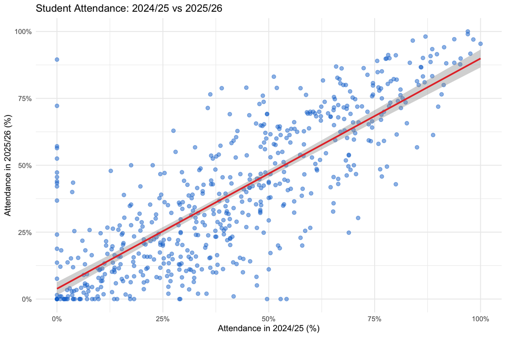

–

### 1.2.2 Within and Across Terms

The chart below show two consistent patterns. First, attendance declines progressively within each term: the later the week, the lower the average attendance rate, and this within-term erosion is visible in both Term 1 and Term 2. Second, attendance in Term 2 is substantially and consistently lower than attendance in the equivalent week of Term 1 — the gap opens from the very first week of the second term and is maintained throughout. These two patterns — within-term decline and a Term 2 level shift — are both confirmed by the multivariate model, which shows that they persist after controlling for timetabling, student characteristics, and module-level factors.

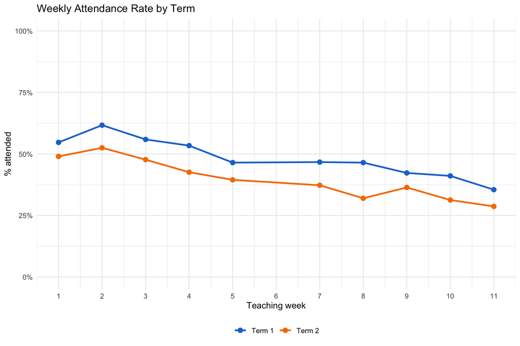

### 1.2.3 Day of Week

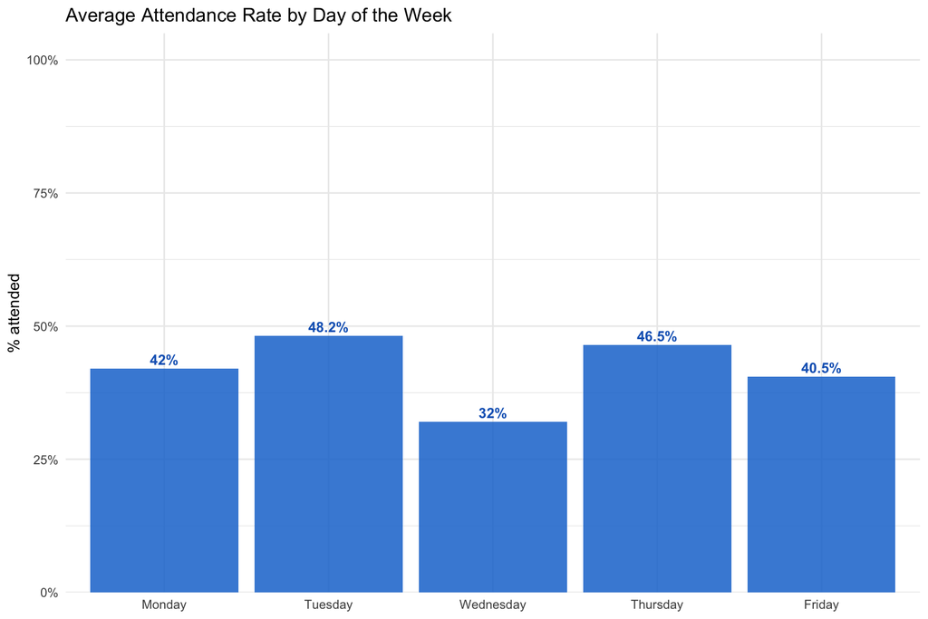

### 1.2.4 Attendance by Time of the Day

The charts below show that session start time is also associated with attendance. Attendance is highest for sessions scheduled around the middle of the day and lower for sessions at the extremes of the teaching day — early morning slots and late afternoon slots both see reduced attendance compared to midday sessions. The second chart, which recodes start time as distance from 13:00, makes this pattern particularly clear: the further a session is from lunchtime, the lower the average attendance. This relationship is confirmed by the multivariate model.

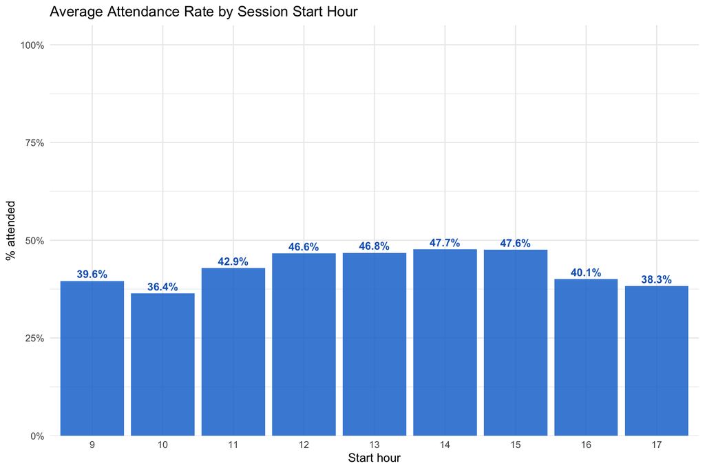

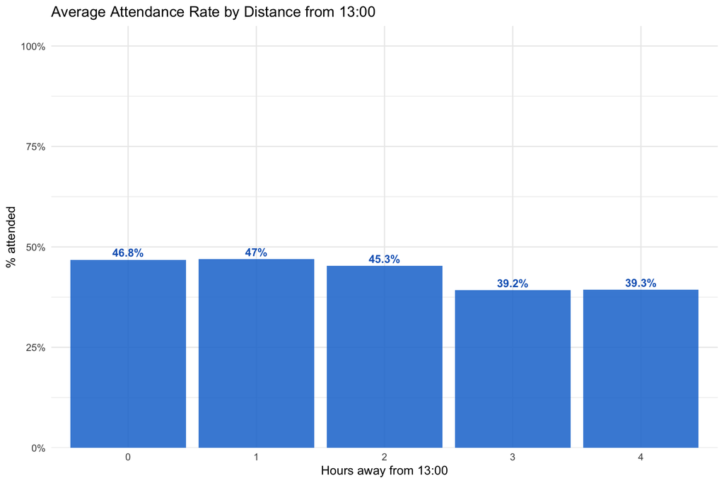

### 1.2.5 Year of Study

The chart below shows raw attendance rates by year of study. In the descriptive data, second- and third-year students attend at lower rates than first-year students on average. However, this raw difference should be interpreted cautiously: older cohorts tend to have less favourable timetabling conditions — more Friday sessions, earlier start times, and more dispersed schedules — which independently reduce attendance. The multivariate model accounts for these differences and finds that a substantial cohort effect persists even after holding timetabling factors constant, confirming that year of study has an independent negative association with attendance beyond what can be explained by scheduling alone.

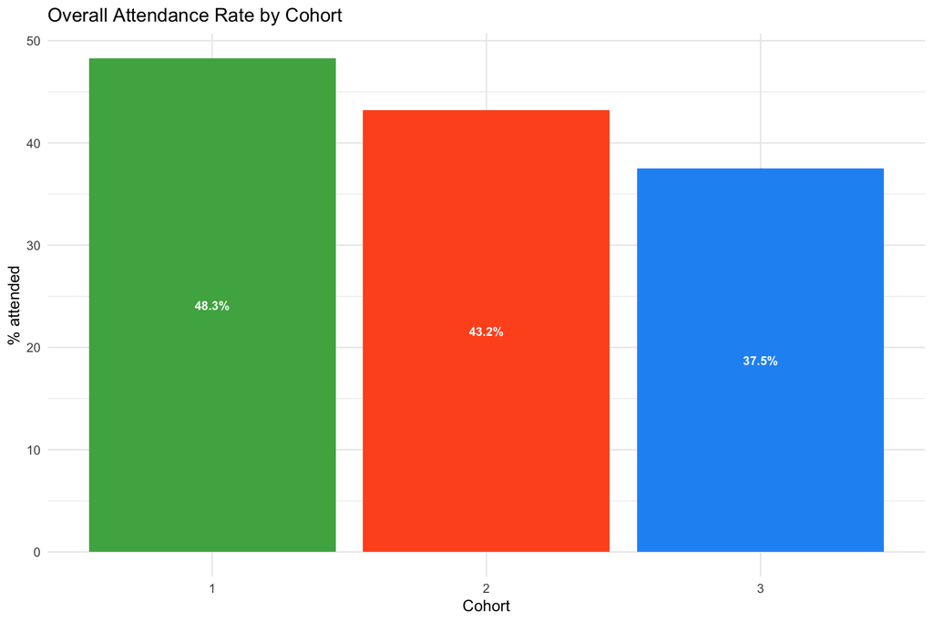

### 1.2.6 Lecture Capture

The boxplot below compares session-level attendance rates between modules with and without lecture capture. Sessions in modules that record lectures show a modestly higher median attendance than those that do not. This challenges the common concern that recording lectures encourages students to skip — at least in this department and year. The positive association in the raw data is confirmed by the multivariate model.

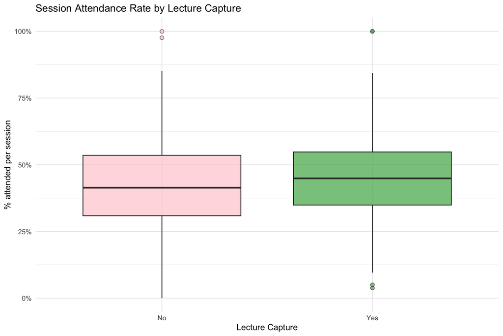

### 1.2.7 Class Size

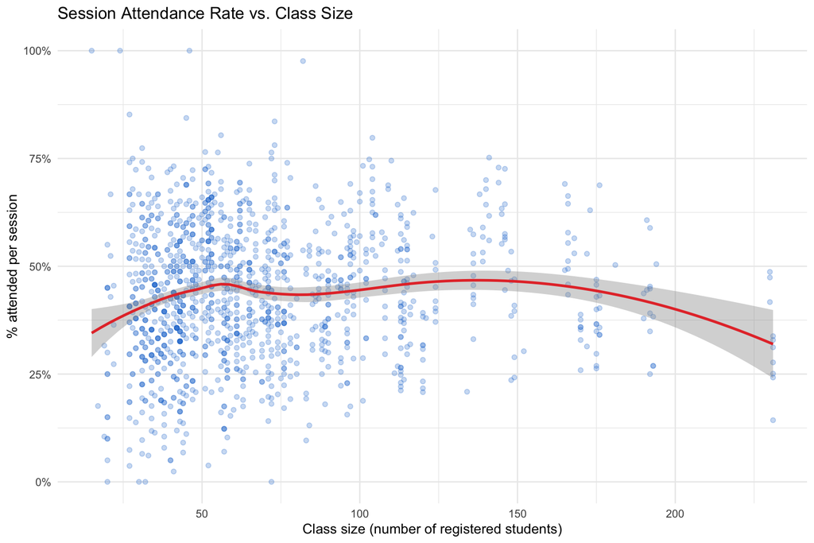

### 1.2.8 Number of Classes in the Day

The chart below shows average daily attendance by the number of different modules a student has scheduled on the same day. Students with more modules on a given day attend a slightly higher proportion of their classes that day than students with a single isolated session. The pattern is modest but consistent: students who have already made the journey in for one session appear more likely to stay for subsequent classes, reducing the marginal cost of each additional session. This small positive association is confirmed by the multivariate model. Taken together with the day-of-week evidence, these findings offer limited but directionally consistent support for timetable consolidation: clustering teaching into fewer, fuller days may deliver a small attendance benefit relative to spreading sessions thinly across the week.

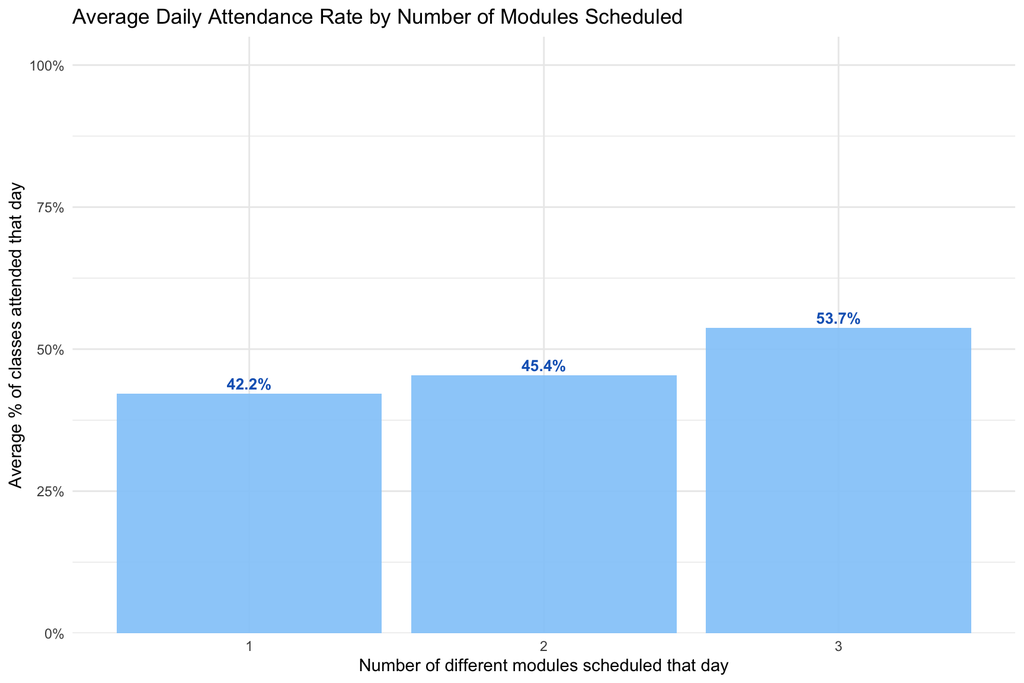

### 1.2.9 Distance from Campus

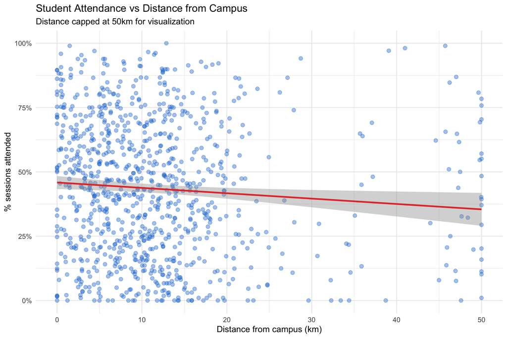

### 1.2.10 Teacher Profile

The boxplot below compares session-level attendance rates between sessions taught by module convenors or permanent staff and those taught by visiting lecturers. In the raw data, the distributions overlap substantially and the difference in medians is negligible. This absence of a bivariate association is confirmed by the multivariate model: after controlling for other session characteristics, the identity of the lecturer — convenor versus visiting — has no meaningful independent effect on attendance.

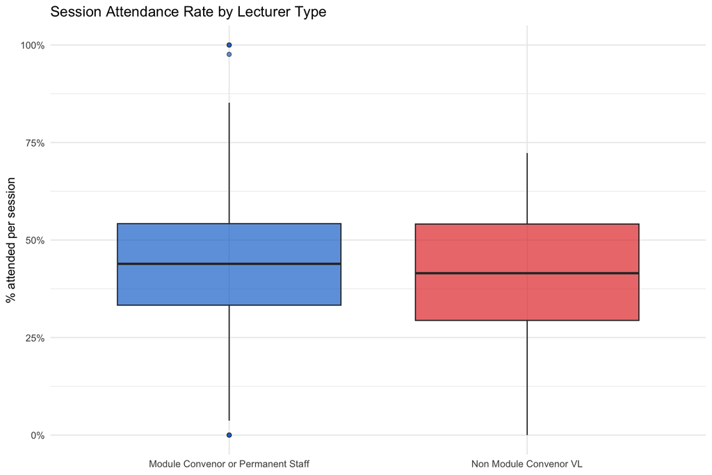

## 1.3 Statistical Analysis

### 1.3.1 Model Specification and Interpretation

The regression model incorporates a comprehensive set of predictors covering student characteristics (e.g. prior attendance history, visa status), session attributes (e.g. day of week, time of day, lecture capture availability), and module-level factors (e.g. class size, timetable consolidation). A random intercept for students is included to account for the fact that the same student appears across multiple session records, ensuring that the fixed-effect estimates reflect within-student variation rather than between-student differences. By holding all other factors constant simultaneously, the model isolates the independent contribution of each predictor.

Effect sizes are reported as odds ratios (OR): values above 1 indicate higher odds of attending, values below 1 lower odds. An important clarification on language: an OR does **not** express a percentage-point change in the attendance rate. It expresses a *relative* change in the odds of attending compared to the reference group or baseline. For example, an OR of 0.84 means the odds of attending are 16% lower — but if the baseline attendance rate is around 70%, this translates to roughly a 3–4 percentage point reduction in the actual probability of attending, not 16 points. Where the text below says a factor “increases/reduces the odds by X%”, this always refers to this relative change in odds. Because the large sample size naturally produces statistically significant p-values across the board, confidence intervals and the magnitude of the odds ratios are used to assess the practical importance of each finding.

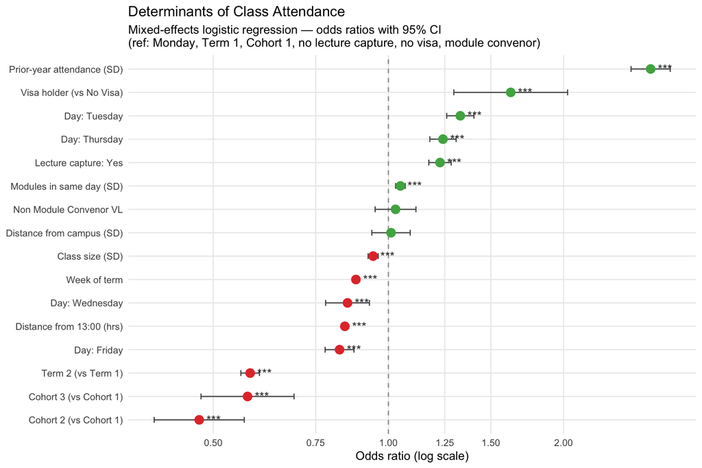

### 1.3.2 Key Findings from the Model

[output not shown]

# 2 Online Engagement via Moodle

## 2.1 Data

The data for this section are drawn from the Moodle activity logs capturing student engagement across all activities and sections of the Moodle pages for the undergraduate modules offered by the IP Department during the 2025/26 academic year. The logs record each instance of a student viewing or interacting with a Moodle resource, along with a timestamp, the student’s name, the module, and the type of component accessed. Data was extracted on 29 April 2026 and therefore covers the full teaching period for both Term 1 and Term 2 as well as the revision and assessment period that followed (partially truncated for Term 2 given the extraction date). Prior to analysis, the logs were cleaned to remove entries generated by teaching staff and course administrators.

The analysis focuses on student interactions with discrete learning resources — specifically files, URLs, forum posts, external tools, and SCORM packages — and excludes course-level navigation events and assignment submission pages. Each resource was assigned to one of the following categories based on its name and component type:

- **Lecture Slides**: Files whose names include terms such as “slides”, “lecture notes”, or “PowerPoint”.
- **Lecture Recordings**: Links or external tools pointing to recorded sessions, identified by terms such as “recording”, “Panopto”, “Echo”, “Replay”, or “video”.
- **Pre-recorded Video**: SCORM packages, which are used on some modules to host embedded instructional videos.
- **Assessment Guidance**: Resources related to assignments, coursework, or academic writing, identified by terms such as “assignment”, “marking criteria”, “essay guidance”, “submission”, or “rubric”.
- **Linked Learning Resources**: External readings and linked materials, identified by terms such as “reading list”, “readings”, author–date citations, journal or chapter references, policy briefs, and similar patterns.
- **Learning Activities**: In-class and preparatory tasks, identified by terms such as “worksheet”, “seminar brief”, “seminar guide”, “exercise”, or “problem set”.

Resources that did not match any of these patterns were flagged as “Unclassified” and subjected to a further manual review, with a subset reclassified by inspection of the resource title.

Two important caveats apply to how engagement with these resources should be interpreted. First, the Moodle logs record only the act of clicking on a link to open a resource — they do not capture what the student did afterwards. There is no way to determine from this data whether a student read an article in full, watched a video to completion, or simply opened and immediately closed a file. A single click is recorded identically regardless of the depth of engagement that followed. Second, the coverage of learning resources in this dataset is necessarily limited to materials that are directly linked within the Moodle page. In cases where a module convenor listed required readings in text without creating individual hyperlinks — expecting students to locate the materials independently through the university library — those readings are invisible to this analysis. Similarly, where a module provides a single link to an electronic reading list (for example via the university’s reading list system), only that one click is recorded: the data does not capture whether the student then opened any of the individual readings within the list. The engagement figures reported below should therefore be understood as a measure of how students interact with the Moodle page itself, rather than a complete picture of their broader study activity.

## 2.2 Moodle Access across IP Modules

| Module | Event Context | Resource Type | Students (n) | Students (%) |
| --- | --- | --- | --- | --- |
| IP1015 | File: IP1015 Assignment Guidance | Assessment Guidance | 111 | 77.1 |
| IP1015 | URL: AI Guidance for Students | Assessment Guidance | 17 | 11.8 |
| IP1015 | File: Week 1 Worksheet | Learning Activities | 89 | 61.8 |
| IP1015 | File: Week 2 Worksheet | Learning Activities | 80 | 55.6 |
| IP1015 | File: Week 3 Worksheet | Learning Activities | 74 | 51.4 |
| IP1015 | File: Week 4 Worksheet | Learning Activities | 57 | 39.6 |
| IP1015 | File: Week 5 Worksheet | Learning Activities | 42 | 29.2 |
| IP1015 | File: Week 9 Worksheet | Learning Activities | 36 | 25 |
| IP1015 | File: Week 7 Worksheet | Learning Activities | 29 | 20.1 |
| IP1015 | File: Week 8 Worksheet | Learning Activities | 26 | 18.1 |

[output cut: 2696 more lines]

## 2.3 How much students access learning resources on Moodle?

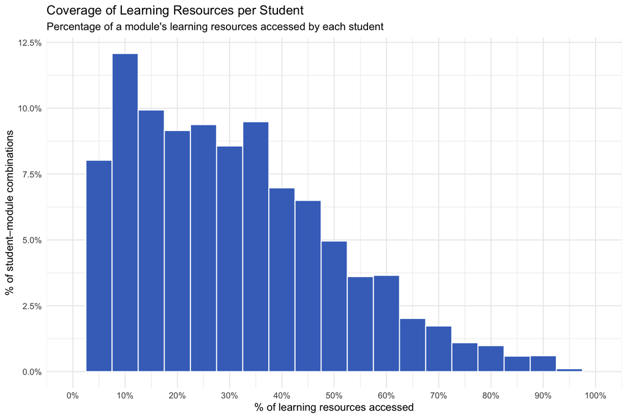

The histogram shows that most student–module combinations are concentrated in the lower end of the resource coverage distribution: the majority of students access only a small fraction of the classified resources posted to a module’s Moodle page, with coverage for the typical student falling well below 50%. The distribution is strongly right-skewed, with a large share of student–module combinations clustering in the 0–25% range and progressively fewer observations at higher coverage levels. A small tail of students access a much larger proportion of the available resources — potentially those preparing intensively for assessments or revisiting material across the term. This pattern suggests that while Moodle resources are accessed by most students, full or near-full engagement with the resource catalogue is the exception rather than the norm.

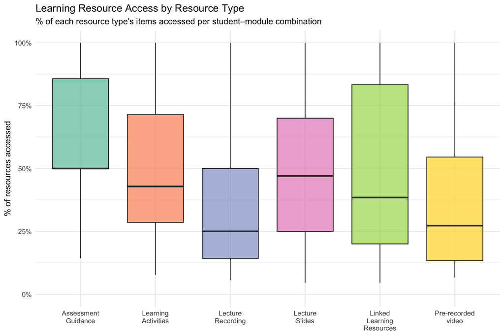

Breaking coverage down by resource type suggests from differences in the extent to which students engage with different categories of material. **Assessment Guidance** resources tend to show the highest median coverage: a large proportion of students access most or all of the assignment-related materials posted to a module, reflecting the universal pressure to engage with marking criteria, rubrics, and submission guidance regardless of other engagement habits. **Lecture Slides** also show relatively high median coverage, consistent with their role as a core reference point that most students return to at some point during or after the teaching period. By contrast, **Linked Learning Resources** — external readings and library links — show notably lower and more dispersed coverage, suggesting that students are selective about which readings they access and that many items on the reading list go unclicked. **Learning Activities** such as worksheets and seminar briefs sit at an intermediate level, with wide variability indicating that some students engage thoroughly with preparatory materials while others do not. Where present, **Lecture Recordings** and **Pre-recorded Video** show highly variable coverage, likely reflecting the mix of students who use them for review and those who rely on them as a substitute for missed sessions. Across all types, the interquartile ranges are wide, underscoring that individual behaviour varies considerably even within the same module and resource category.

## 2.4 When do students access learning resources on Moodle?

### 2.4.1 Frequency of access across days and weeks of the term

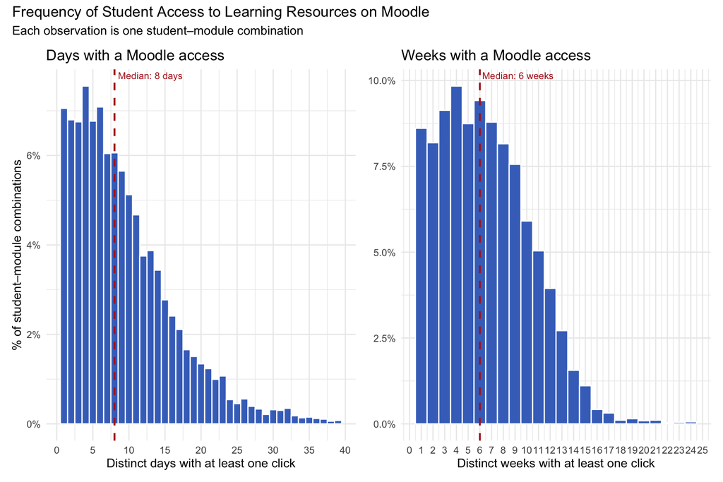

With 10 weeks of teaching per module, a student engaging consistently throughout the term would be expected to access Moodle in all 10 weeks and on roughly 10 to 20 distinct days (assuming one to two access days per week). The median lines in each panel provide a useful reference point.

### 2.4.2 Weekly pattern of Moodle activity during and after the teaching period

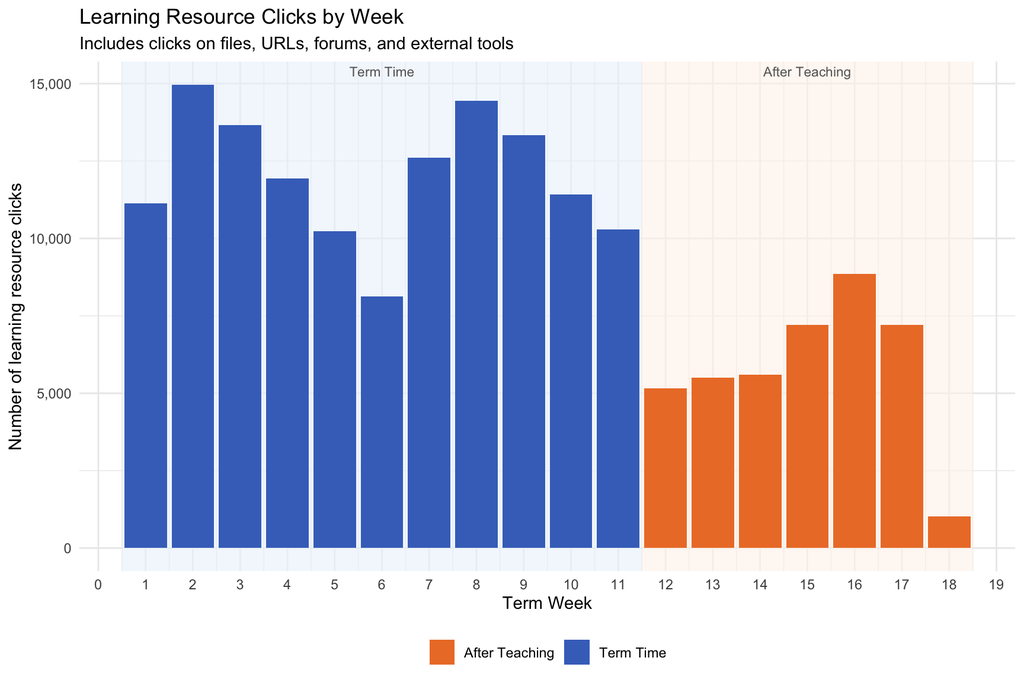

The chart reveals a clear contrast in the volume and timing of Moodle engagement across the teaching period. During term time (weeks 1–11), resource clicks are consistently high, with activity maintained across all teaching weeks and no pronounced single peak — suggesting that students engage with Moodle resources steadily rather than concentrating activity in particular weeks. There is some variation week to week, which may reflect the mix of modules included: because the x-axis pools Term 1 and Term 2 modules by their relative week number, each bar aggregates activity from both cohorts.

### 2.4.3 Moodle Engagement and Student Profiles

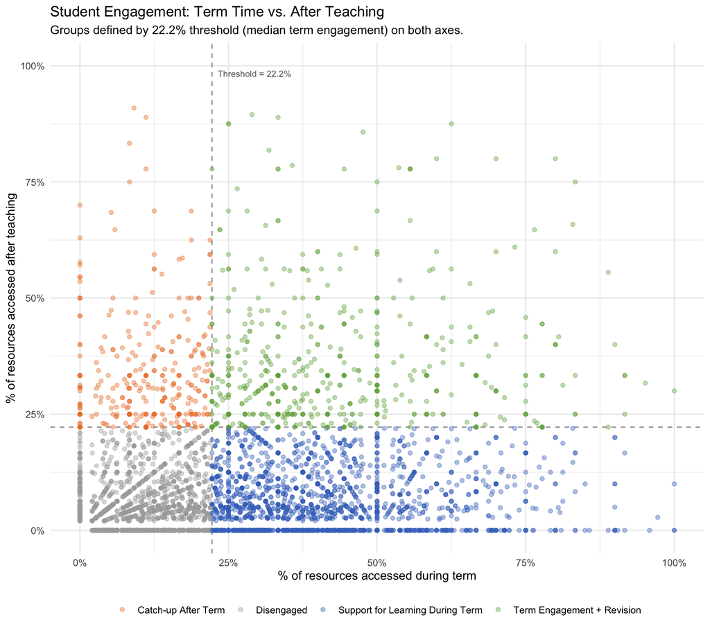

Each point in the scatterplot represents one student–module combination. The x-axis shows the percentage of the module’s classified learning resources that the student accessed during term time; the y-axis shows the same measure for the period after teaching ended. Both axes use the same denominator as the coverage histogram above — the total number of classified (non-unclassified) resources posted to that module’s Moodle page — so the two charts are directly comparable.

Points that lie above the 45-degree diagonal are students who accessed a higher share of resources after the end of teaching than during term time; points below the diagonal accessed more during term. The distance of a point from the origin reflects the overall breadth of engagement: a point near (0, 0) accessed very few resources in either period, while a point near (100, 100) accessed virtually everything both during and after the term.

The four colours identify four distinct engagement patterns, defined by whether each axis exceeds the median level of term-time engagement (the dashed lines, set at the same threshold on both axes):

- **Disengaged** (grey): below the threshold in both periods — students who engaged with relatively few resources at any point in the year.
- **Support for Learning During Term** (blue): above the threshold during term but below after teaching — students who used Moodle actively while teaching was running but did not return heavily afterwards.
- **Catch-up After Term** (orange): below the threshold during term but above after teaching — students who engaged relatively little while teaching was running but accessed resources more intensively once the term ended.
- **Term Engagement + Revision** (green): above the threshold in both periods — students who engaged broadly during term and continued to access resources after teaching, suggesting use for revision.

It is important to note that the placement of the dashed threshold lines — and therefore the relative size of each group — depends on the chosen cutoff. Here the threshold is set at the median level of term-time engagement, which is a pragmatic but ultimately arbitrary choice. Shifting the threshold upward or downward would reallocate students between groups, particularly between the Disengaged and Support for Learning During Term categories, or between Catch-up and Term Engagement + Revision.

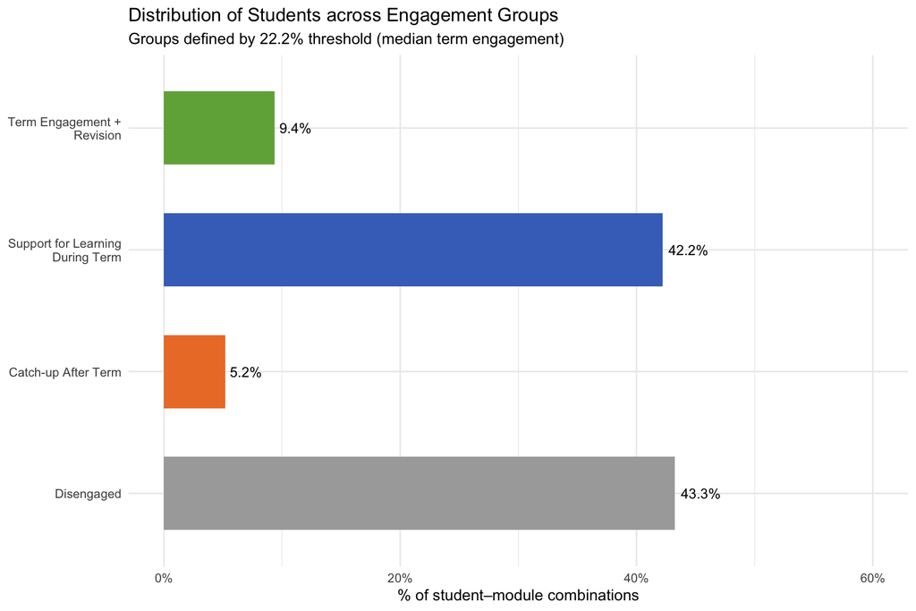

## 2.5 Moodle Engagement and In-Person Attendance

### 2.5.1 Overall relationship between attendance and Moodle resource access

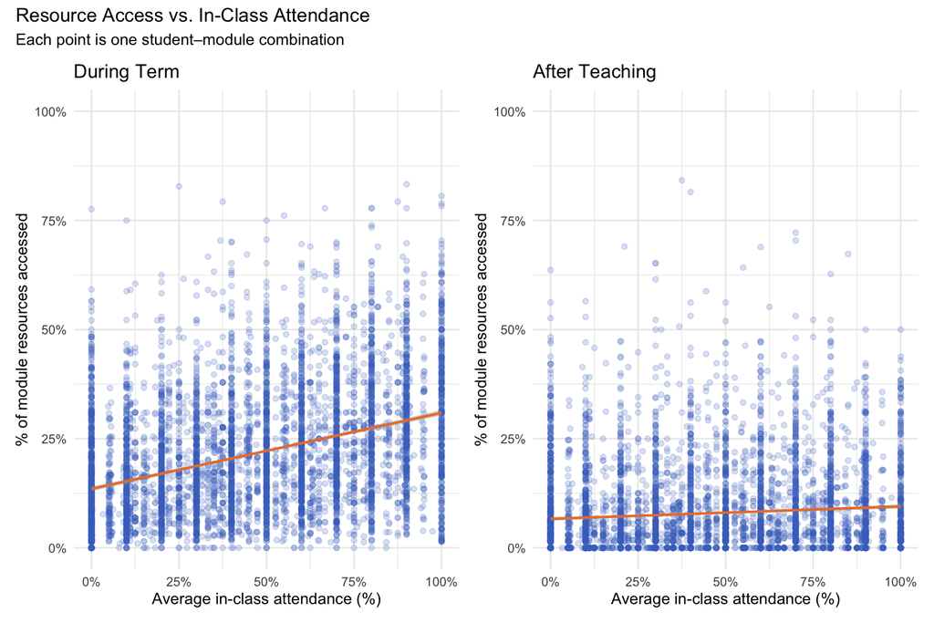

The two panels reveal a striking asymmetry in the relationship between in-person attendance and online resource access. During term time, there is a positive association between the two: students who attend class more regularly also tend to access a larger share of the module’s Moodle resources. The trend line slopes clearly upward, indicating that in-person attendance and online engagement are complements rather than substitutes — students who show up to teaching sessions are also, on average, more likely to engage with the supporting materials posted on Moodle. This is consistent with a broader pattern of academic engagement in which attendance and independent study reinforce one another.

After the end of teaching, however, this relationship largely disappears. The trend line in the right panel is essentially flat, indicating that post-teaching Moodle access is unrelated to how regularly a student attended during the term. Students who attended very rarely are just as likely to return to Moodle resources after the term as those who attended every session. This suggests that post-teaching Moodle engagement is driven by different motivations — most plausibly assessment preparation and revision — which cut across the attendance patterns observed during term. Students who were disengaged in person during the term may be catching up on material they missed; students who attended regularly may be consolidating what they already encountered in class. Either way, the absence of a relationship after teaching implies that Moodle serves a genuinely different function in the two periods: as a complement to active learning during term, and as a revision and catch-up resource afterwards.

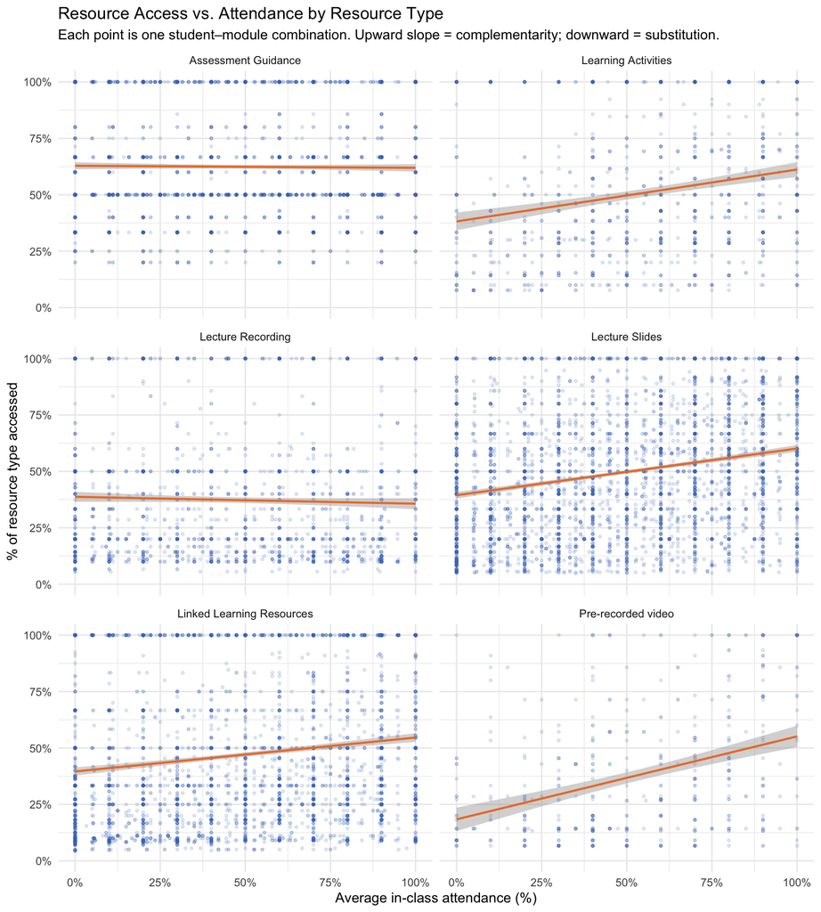

### 2.5.2 Resource Type Differences in Attendance–Engagement Relationship

Breaking the overall attendance–engagement relationship down by resource type reveals important differences in how strongly — and in what direction — different kinds of Moodle content are associated with in-person attendance.

For **Lecture Slides** and **Learning Activities** (worksheets, seminar briefs, and similar preparatory tasks), the positive relationship with attendance is clearest. Students who attend more regularly access a higher proportion of these resources, consistent with a pattern in which in-person participation and online preparation reinforce each other: students who show up to seminars and lectures are more likely to have engaged with the supporting slides and session materials beforehand or in follow-up.

**Linked Learning Resources** — external readings and library links — show a positive but relatively shallow slope. Regular attenders are somewhat more likely to access readings, consistent with the general complementarity between in-person and online engagement, but the relationship is weaker than for slides or learning activities.

### 2.5.3 Attendance Patterns across Engagement Groups

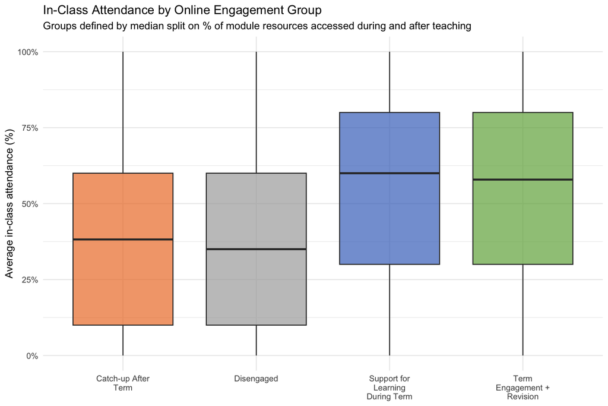

The boxplot reveals a clear two-tier structure rather than a clean four-way ordering. The dominant divide is between students who engaged actively with Moodle resources during the teaching period and those who did not — irrespective of what they did after teaching ended.

The two groups characterised by low term-time Moodle engagement — **Catch-up After Term** and **Disengaged** — both show substantially lower in-class attendance, with median rates in the 35–40% range. Again, the two groups are very similar to each other: students who later returned to Moodle for catch-up did not attend meaningfully more during the term than those who remained disengaged throughout. The post-teaching Moodle activity in the Catch-up group therefore reflects genuine compensatory behaviour — accessing resources after the fact rather than as part of active in-term participation.

The key implication is that it is **term-time** Moodle engagement, not post-teaching revisiting, that maps onto higher in-person attendance. Students who engage with both modes of learning simultaneously during the teaching period are the ones who attend most regularly; post-teaching access is a separate behaviour that does not distinguish attenders from non-attenders. This further confirms that in-person and online engagement during term time are complements, while post-teaching Moodle use serves a functionally different purpose.